# 언어심리학을 위한 데이터 사이언스 7주차: 데이터 사이언스 #3-4 (데이터 분석)

고려대학교 일반대학원 심리학과

2022년 5월 2일 월요일 5-6교시

# 1. 기술통계 분석

## (1) **psych** 패키지의 `describe` 함수를 사용할 경우

- **psych** 패키지
  - 다양한 통계분석을 가능하게 해주는 패키지.
  - 기술통계 관련 함수: `describe`, `describeBy` 등.

> describe(변수명)

```r
# tidyverse 패키지 불러오기
library(tidyverse)
# 2010년 미국 총기살인 사건 통계
library(dslabs)
data(murders)
head(murders)
```

```
##        state abb region population total
## 1    Alabama  AL  South    4779736   135
## 2     Alaska  AK   West     710231    19
## 3    Arizona  AZ   West    6392017   232
## 4   Arkansas  AR  South    2915918    93
## 5 California  CA   West   37253956  1257
## 6   Colorado  CO   West    5029196    65
```

```r
# describe 함수로 주별 총기살인 건수 기술통계량 계산하기.
library(psych)
describe(murders$total); describe(murders[, 5])
```

```
##    vars  n   mean     sd median trimmed    mad min  max range skew kurtosis
## X1    1 51 184.37 236.13     97  138.41 126.02   2 1257  1255 2.36     6.88
##       se
## X1 33.06
```

```
##    vars  n   mean     sd median trimmed    mad min  max range skew kurtosis
## X1    1 51 184.37 236.13     97  138.41 126.02   2 1257  1255 2.36     6.88
##       se
## X1 33.06
```

```r
# describe 함수로 주별 인구 수와 총기살인 건수 기술통계량 동시 계산하기.
describe(murders[, 4:5])
```

```
##            vars  n       mean         sd  median    trimmed        mad    min
## population    1 51 6075769.18 6860669.07 4339367 4692546.63 3725812.35 563626
## total         2 51     184.37     236.13      97     138.41     126.02      2
##                 max    range skew kurtosis        se
## population 37253956 36690330 2.48     7.26 960685.83
## total          1257     1255 2.36     6.88     33.06
```

## (2) **pastecs** 패키지의 `stat.desc` 함수를 사용할 경우

- **pastecs** 패키지
  - 기술통계 분석을 가능하게 해주는 패키지.
  - 기술통계 관련 함수: `stat.desc`, `stat.pen` 등.

> stat.desc(변수명, basic = F, norm = T)

```r
library(pastecs)
# stat.desc 함수로 주별 총기살인 건수 기술통계량 계산하기.
stat.desc(murders$total, basic = F, norm = T)
```

```
##       median         mean      SE.mean CI.mean.0.95          var      std.dev
## 9.700000e+01 1.843725e+02 3.306427e+01 6.641155e+01 5.575556e+04 2.361261e+02
##     coef.var     skewness     skew.2SE     kurtosis     kurt.2SE   normtest.W
## 1.280701e+00 2.361922e+00 3.541494e+00 6.884493e+00 5.247964e+00 7.283564e-01
##   normtest.p
## 2.217883e-08
```

```r
stat.desc(murders$total, basic = T, norm = F)
```

```
##      nbr.val     nbr.null       nbr.na          min          max        range
##    51.000000     0.000000     0.000000     2.000000  1257.000000  1255.000000
##          sum       median         mean      SE.mean CI.mean.0.95          var
##  9403.000000    97.000000   184.372549    33.064274    66.411550 55755.558431
##      std.dev     coef.var
##   236.126149     1.280701
```

```r
stat.desc(murders$total, basic = F, norm = F)
```

```
##       median         mean      SE.mean CI.mean.0.95          var      std.dev
##    97.000000   184.372549    33.064274    66.411550 55755.558431   236.126149
##     coef.var
##     1.280701
```

```r
# 지수 사용 금지.
options(scipen = 999)

# 소수점 이하 3자리까지만 보여주기.
round(stat.desc(murders$total, basic = F, norm = T), 3)
```

```
##       median         mean      SE.mean CI.mean.0.95          var      std.dev
##       97.000      184.373       33.064       66.412    55755.558      236.126
##     coef.var     skewness     skew.2SE     kurtosis     kurt.2SE   normtest.W
##        1.281        2.362        3.541        6.884        5.248        0.728
##   normtest.p
##        0.000
```

```r
# stat.desc 함수로 주별 인구 수와 총기살인 건수 기술통계량 동시 계산하기.
stat.desc(murders[, 4:5], basic = F, norm = T)
```

```
##                                 population                total
## median              4339367.00000000000000    97.00000000000000
## mean                6075769.17647058796138   184.37254901960785
## SE.mean              960685.82594359957147    33.06427443257152
## CI.mean.0.95        1929594.26956506236456    66.41154969654174
## var          47068780064615.75000000000000 55755.55843137254851
## std.dev             6860669.06829179078341   236.12614940190878
## coef.var                  1.12918527169545     1.28070122508746
## skewness                  2.47931703743292     2.36192223584741
## skew.2SE                  3.71751684828539     3.54149371521843
## kurtosis                  7.25876526985865     6.88449346330475
## kurt.2SE                  5.53326660334469     5.24796385407718
## normtest.W                0.71739936415937     0.72835637632685
## normtest.p                0.00000001372316     0.00000002217883
```

## (3) **modeest** 패키지로 최빈값(mode) 계산하기

- **modeest** 패키지
  - 최빈값 추출을 가능하게 해주는 패키지. **psych**나 **pastecs**로는 최빈값 추출 불가.
  - 최빈값 관련 함수: `mlv`.

> mlv(변수명, method = “최빈값 추출 방법”)

```r
# mlv 함수로 주별 총기살인 건수 최빈값 계산하기.
library(modeest)
mlv(murders$total, method = "mfv") # most frequent value(s)
```

```
## [1]  5 12 93 97
```

```r
mlv(murders$total, method = "hsm") # the half sample mode
```

```
## [1] 5
```

```r
mlv(murders$total, method = "vieu") #  Vieu mode estimator
```

```
## [1] 1257
```

```r
mlv(murders$total, method = "meanshift") # meanshift mode estimator
```

```
## [1] 54.83989
## attr(,"iterations")
## [1] 19
```

## (3) 집단별로 기술통계값을 각각 계산할 경우

- `by` 함수를 사용하는 경우

> by(data = 데이터, INDICES = 집단/조건 변수, FUN = 적용하고자 하는 함수)

```r
# region이라는 집단변수에 따라 4개 지역별 총기살인 건수 기술통계량을 계산할 경우: describe 함수 사용 시.
by(data = murders$total, INDICES = murders$region, FUN = describe)
```

```
## murders$region: Northeast
##    vars n   mean     sd median trimmed   mad min max range skew kurtosis    se
## X1    1 9 163.22 200.19     97  163.22 136.4   2 517   515 0.76    -1.24 66.73
## ------------------------------------------------------------
## murders$region: South
##    vars  n   mean     sd median trimmed    mad min max range skew kurtosis
## X1    1 17 246.76 212.86    207   224.2 142.33  27 805   778 1.33     0.89
##       se
## X1 51.63
## ------------------------------------------------------------
## murders$region: North Central
##    vars  n   mean     sd median trimmed   mad min max range skew kurtosis    se
## X1    1 12 152.33 154.22     80   141.1 99.33   4 413   409 0.54    -1.58 44.52
## ------------------------------------------------------------
## murders$region: West
##    vars  n mean    sd median trimmed mad min  max range skew kurtosis    se
## X1    1 13  147 339.1     36      59  43   5 1257  1252 2.66     5.84 94.05
```

```r
# region이라는 집단변수에 따라 4개 지역별 총기살인 건수 기술통계량을 계산할 경우: stat.desc 함수 사용 시.
by(data = murders$total, INDICES = murders$region, FUN = stat.desc, basic = F, norm = T)
```

```
## murders$region: Northeast
##        median          mean       SE.mean  CI.mean.0.95           var
##    97.0000000   163.2222222    66.7311725   153.8823597 40077.4444444
##       std.dev      coef.var      skewness      skew.2SE      kurtosis
##   200.1935175     1.2265090     0.7609493     0.5305466    -1.2365074
##      kurt.2SE    normtest.W    normtest.p
##    -0.4417018     0.7985919     0.0196786
## ------------------------------------------------------------
## murders$region: South
##        median          mean       SE.mean  CI.mean.0.95           var
##   207.0000000   246.7647059    51.6266667   109.4436444 45310.3161765
##       std.dev      coef.var      skewness      skew.2SE      kurtosis
##   212.8622000     0.8626120     1.3287082     1.2084716     0.8857172
##      kurt.2SE    normtest.W    normtest.p
##     0.4165345     0.8266897     0.0048261
## ------------------------------------------------------------
## murders$region: North Central
##         median           mean        SE.mean   CI.mean.0.95            var
##    80.00000000   152.33333333    44.52073629    97.98947989 23785.15151515
##        std.dev       coef.var       skewness       skew.2SE       kurtosis
##   154.22435448     1.01241371     0.54000966     0.42366857    -1.57897055
##       kurt.2SE     normtest.W     normtest.p
##    -0.64068779     0.83027720     0.02113418
## ------------------------------------------------------------
## murders$region: West
##              median                mean             SE.mean        CI.mean.0.95
##     36.000000000000    147.000000000000     94.049836761537    204.916990964146
##                 var             std.dev            coef.var            skewness
## 114989.833333333328    339.101508892740      2.306812985665      2.664818480412
##            skew.2SE            kurtosis            kurt.2SE          normtest.W
##      2.161822652346      5.844678328815      2.453944079542      0.446685369144
##          normtest.p
##      0.000004092683
```

```r
# region이라는 집단변수에 따라 4개 지역별 총기살인 건수 최빈값을 계산할 경우: mlv 함수 사용 시.
by(murders$total, murders$region, mlv, method = "mfv")
```

```
## murders$region: Northeast
## [1]   2   5  11  16  97 118 246 457 517
## ------------------------------------------------------------
## murders$region: South
##  [1]  27  38  93  99 111 116 120 135 207 219 250 286 293 351 376 669 805
## ------------------------------------------------------------
## murders$region: North Central
##  [1]   4   8  21  32  53  63  97 142 310 321 364 413
## ------------------------------------------------------------
## murders$region: West
## [1] 12
```

- `describeBy` 함수를 사용하는 경우

> describeBy(data = 데이터 또는 데이터프레임, 집단/조건 변수)

```r
describeBy(murders, murders$region) # murders 데이터셋의 모든 변수에 대해 기술통계량 계산.
```

```
##
##  Descriptive statistics by group
## group: Northeast
##            vars n       mean         sd  median    trimmed        mad    min
## state*        1 9       5.00       2.74       5       5.00       2.97      1
## abb*          2 9       5.00       2.74       5       5.00       2.97      1
## region*       3 9       1.00       0.00       1       1.00       0.00      1
## population    4 9 6146360.00 6469174.00 3574097 6146360.00 4371232.61 625741
## total         5 9     163.22     200.19      97     163.22     136.40      2
##                 max    range skew kurtosis         se
## state*            9        8 0.00    -1.60       0.91
## abb*              9        8 0.00    -1.60       0.91
## region*           1        0  NaN      NaN       0.00
## population 19378102 18752361 0.85    -0.76 2156391.33
## total           517      515 0.76    -1.24      66.73
## ------------------------------------------------------------
## group: South
##            vars  n       mean         sd  median   trimmed        mad    min
## state*        1 17       9.00       5.05       9       9.0       5.93      1
## abb*          2 17       9.00       5.05       9       9.0       5.93      1
## region*       3 17       2.00       0.00       2       2.0       0.00      2
## population    4 17 6804378.47 6516176.53 4625364 5995143.3 2551170.61 601723
## total         5 17     246.76     212.86     207     224.2     142.33     27
##                 max    range skew kurtosis         se
## state*           17       16 0.00    -1.41       1.22
## abb*             17       16 0.00    -1.41       1.22
## region*           2        0  NaN      NaN       0.00
## population 25145561 24543838 1.62     1.72 1580404.95
## total           805      778 1.33     0.89      51.63
## ------------------------------------------------------------
## group: North Central
##            vars  n       mean         sd    median   trimmed        mad    min
## state*        1 12       6.50       3.61       6.5       6.5       4.45      1
## abb*          2 12       6.50       3.61       6.5       6.5       4.45      1
## region*       3 12       3.00       0.00       3.0       3.0       0.00      3
## population    4 12 5577250.08 4071915.73 5495455.5 5342377.8 4678679.37 672591
## total         5 12     152.33     154.22      80.0     141.1      99.33      4
##                 max    range skew kurtosis         se
## state*           12       11 0.00    -1.50       1.04
## abb*             12       11 0.00    -1.50       1.04
## region*           3        0  NaN      NaN       0.00
## population 12830632 12158041 0.44    -1.25 1175460.82
## total           413      409 0.54    -1.58      44.52
## ------------------------------------------------------------
## group: West
##            vars  n    mean         sd  median trimmed        mad    min
## state*        1 13       7       3.89       7       7       4.45      1
## abb*          2 13       7       3.89       7       7       4.45      1
## region*       3 13       4       0.00       4       4       0.00      4
## population    4 13 5534273 9751150.25 2700551 3102543 2536930.23 563626
## total         5 13     147     339.10      36      59      43.00      5
##                 max    range skew kurtosis         se
## state*           13       12 0.00    -1.48       1.08
## abb*             13       12 0.00    -1.48       1.08
## region*           4        0  NaN      NaN       0.00
## population 37253956 36690330 2.60     5.63 2704482.48
## total          1257     1252 2.66     5.84      94.05
```

```r
describeBy(murders[, 4:5], murders$region) # murders 데이터셋의 population과 total 변수에 대해서만 기술통계량 계산.
```

```
##
##  Descriptive statistics by group
## group: Northeast
##            vars n       mean         sd  median    trimmed       mad    min
## population    1 9 6146360.00 6469174.00 3574097 6146360.00 4371232.6 625741
## total         2 9     163.22     200.19      97     163.22     136.4      2
##                 max    range skew kurtosis         se
## population 19378102 18752361 0.85    -0.76 2156391.33
## total           517      515 0.76    -1.24      66.73
## ------------------------------------------------------------
## group: South
##            vars  n       mean         sd  median   trimmed        mad    min
## population    1 17 6804378.47 6516176.53 4625364 5995143.3 2551170.61 601723
## total         2 17     246.76     212.86     207     224.2     142.33     27
##                 max    range skew kurtosis         se
## population 25145561 24543838 1.62     1.72 1580404.95
## total           805      778 1.33     0.89      51.63
## ------------------------------------------------------------
## group: North Central
##            vars  n       mean         sd  median   trimmed        mad    min
## population    1 12 5577250.08 4071915.73 5495456 5342377.8 4678679.37 672591
## total         2 12     152.33     154.22      80     141.1      99.33      4
##                 max    range skew kurtosis         se
## population 12830632 12158041 0.44    -1.25 1175460.82
## total           413      409 0.54    -1.58      44.52
## ------------------------------------------------------------
## group: West
##            vars  n    mean        sd  median trimmed     mad    min      max
## population    1 13 5534273 9751150.2 2700551 3102543 2536930 563626 37253956
## total         2 13     147     339.1      36      59      43      5     1257
##               range skew kurtosis         se
## population 36690330 2.60     5.63 2704482.48
## total          1252 2.66     5.84      94.05
```

# 2. 데이터 분포 시각화

- 5주차 데이터 시각화 수업자료의 **3. ggplot2 패키지를 사용한 데이터 분포(data distribution) 시각화** 참조.

# 3. 자료변형

- 자료변형의 필요성: 자료가 정규성(normality)을 띠지 않거나 비교대상 자료 간 분산이 동일하지 않을 경우, 자료를 일괄적으로 변형함으로써 문제를 해결할 수 있음.
- 자료변형의 유형
  - 로그 변형(log transformation).
  - *z*-점수 변형(log transformation).
  - 제곱근 변형(square root transformation).
  - 마이너스 제곱 변형(reciprocal transformation).
  - 가장 큰 관찰값에서 개별 관찰값 빼기(reverse score transformation).

## (1) 로그 변형

- 설명: 관찰값을 실수 e(2.71828…)를 밑으로 하는 자연 로그 값으로 변형하기.
- 용례: 정적 편포일 경우, 비교대상 자료 간 분산이 동일하지 않을 경우 사용.

```r
# festival.1 데이터셋 불러오기.
load("festival.1.rda")

# 데이터 변형.
festival.2 <- festival.1 %>%
  mutate(hygiene_score_log = log(hygiene_score))

# 변형 전 분포 확인.
festival.1 %>%
  ggplot(aes(x = hygiene_score)) +
  geom_histogram(aes(y = ..density..), binwidth = 0.1) +
  geom_density(adjust = 2, lwd = 2) +
  facet_wrap(~ day)
```

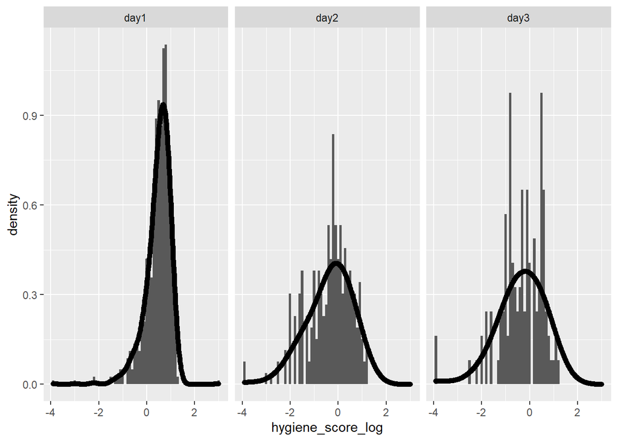

```r
# 변형 후 분포 확인.
festival.2 %>%
  ggplot(aes(x = hygiene_score_log)) +
  geom_histogram(aes(y = ..density..), binwidth = 0.1) +
  geom_density(adjust = 2, lwd = 2) +
  facet_wrap(~ day)
```

## (2) *z*-점수 변형

- 설명: 관찰값을 *z*-점수(평균이 0이고, 표준편차가 1인 *z*-분포를 따르는 값)로 변형하기.
- 용례: 정적 편포일 경우, 비교대상 자료 간 분산이 동일하지 않을 경우 사용.

```r
# 데이터 변형.
festival.2 <- festival.1 %>%
  mutate(hygiene_score_zscore = scale(hygiene_score, center = T, scale = T))

# 변형 전 분포 확인.
festival.1 %>%
  ggplot(aes(x = hygiene_score)) +
  geom_histogram(aes(y = ..density..), binwidth = 0.1) +
  geom_density(adjust = 2, lwd = 2) +
  facet_wrap(~ day)
```

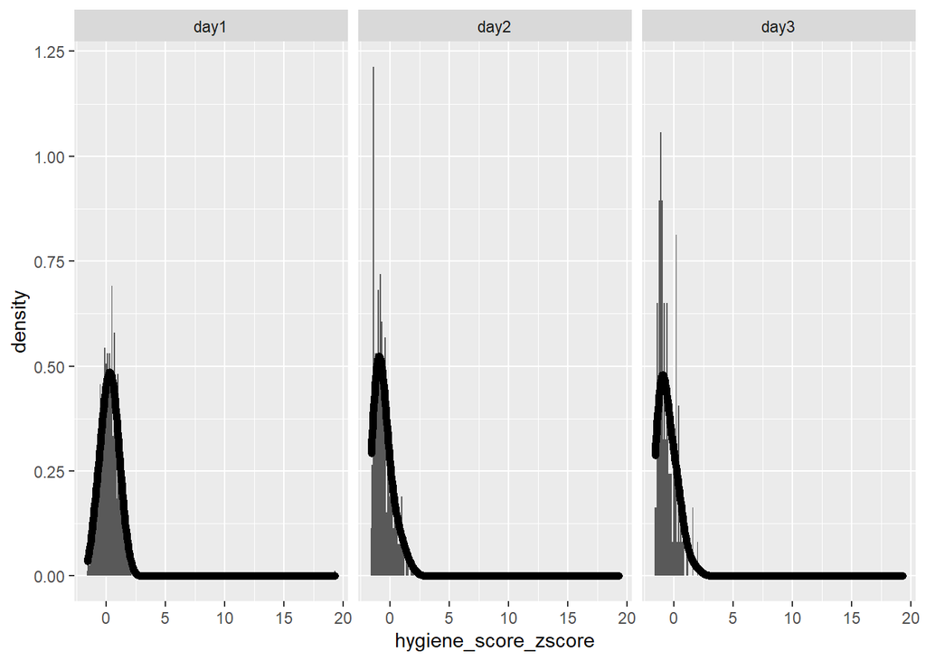

```r
# 변형 후 분포 확인.
festival.2 %>%
  ggplot(aes(x = hygiene_score_zscore)) +
  geom_histogram(aes(y = ..density..), binwidth = 0.1) +
  geom_density(adjust = 2, lwd = 2) +
  facet_wrap(~ day)
```

## (3) 제곱근/세제곱근 변형

- 설명: 관찰값을 제곱근 또는 세제곱근으로 변형하기.
- 용례: 정적 편포일 경우, 비교대상 자료 간 분산이 동일하지 않을 경우.

```r
# 데이터를 제곱근으로 변형하기.
festival.2 <- festival.1 %>%
  mutate(hygiene_score_sqrt = sqrt(hygiene_score))

# 데이터를 세제곱근으로 변형하기.
festival.1 %>%
  mutate(hygiene_score_cuberoot = sign(hygiene_score) * abs(hygiene_score)^(1/3))
```

```
## # A tibble: 2,430 x 5
##    ticknumb gender day   hygiene_score hygiene_score_cuberoot
##       <dbl> <chr>  <chr>         <dbl>                  <dbl>
##  1     2111 Male   day1           2.64                  1.38
##  2     2111 Male   day2           1.35                  1.11
##  3     2111 Male   day3           1.61                  1.17
##  4     2229 Female day1           0.97                  0.990
##  5     2229 Female day2           1.41                  1.12
##  6     2229 Female day3           0.29                  0.662
##  7     2338 Male   day1           0.84                  0.944
##  8     2338 Male   day2          NA                    NA
##  9     2338 Male   day3          NA                    NA
## 10     2384 Female day1           3.03                  1.45
## # ... with 2,420 more rows
```

```r
# 변형 전 분포 확인.
festival.1 %>%
  ggplot(aes(x = hygiene_score)) +
  geom_histogram(aes(y = ..density..), binwidth = 0.1) +
  geom_density(adjust = 2, lwd = 2) +
  facet_wrap(~ day)
```

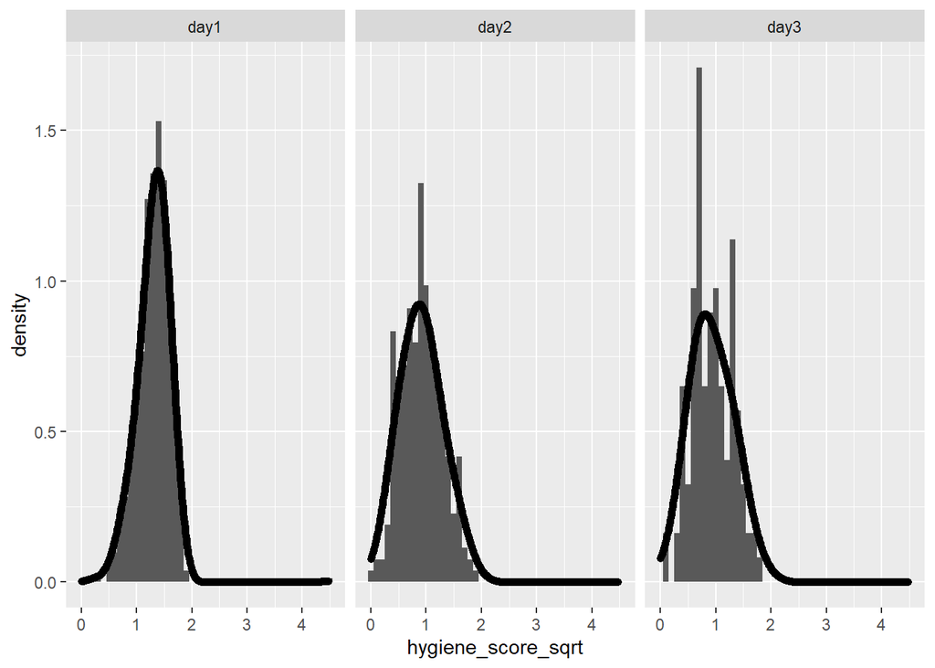

```r
# 변형 후 분포 확인.
festival.2 %>%
  ggplot(aes(x = hygiene_score_sqrt)) +
  geom_histogram(aes(y = ..density..), binwidth = 0.1) +
  geom_density(adjust = 2, lwd = 2) +
  facet_wrap(~ day)
```

## (4) 마이너스 제곱 변형

- 설명: 관찰값에 -1제곱을 곱하기.
- 용례: 정적 편포일 경우, 비교대상 자료 간 분산이 동일하지 않을 경우.

```r
# 데이터 변형.
festival.2 <- festival.1 %>%
  mutate(hygiene_score_reciprocal = 1/(hygiene_score + 1)) # 분모가 0일 경우를 대비하여 1을 더하기.

# 변형 전 분포 확인.
festival.1 %>%
  ggplot(aes(x = hygiene_score)) +
  geom_histogram(aes(y = ..density..), binwidth = 0.1) +
  geom_density(adjust = 2, lwd = 2) +
  facet_wrap(~ day)
```

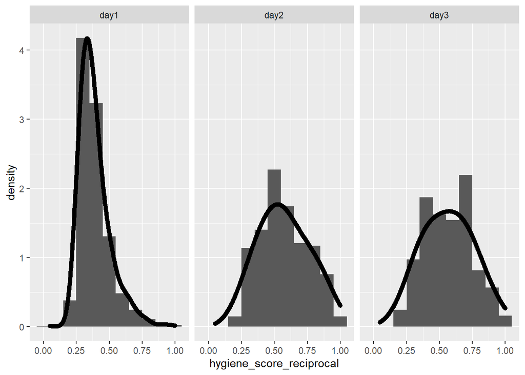

```r
# 변형 후 분포 확인.
festival.2 %>%
  ggplot(aes(x = hygiene_score_reciprocal)) +
  geom_histogram(aes(y = ..density..), binwidth = 0.1) +
  geom_density(adjust = 2, lwd = 2) +
  facet_wrap(~ day)
```

## (5) 가장 큰 관찰값에서 개별 관찰값 빼기

- 설명: 해당 데이터 중 가장 큰 관찰값으로부터 개별 관찰값을 빼기. 분포가 정반대로 바뀌므로 반드시 -1을 다시 곱해주어야 함.
- 용례: 부적 편포일 경우.

```r
# 일자별 최댓값 구하기.
festival.1.max <- festival.1 %>%
  group_by(day) %>%
  summarise(max = max(hygiene_score, na.rm =T)) %>%
  pull()

# 가장 큰 관찰값에서 개별 관찰값 빼기.

festival.2 <- festival.1 %>%
  mutate(hygiene_score_maxsub = case_when(day == "day1" ~ -1 *(festival.1.max[1] - hygiene_score),
                                          day == "day2" ~ -1 *(festival.1.max[2] - hygiene_score),
                                          day == "day3" ~ -1 *(festival.1.max[3] - hygiene_score)))

festival.2 <- festival.1 %>%
  mutate(hygiene_score_maxsub = case_when(day == "day1" ~ hygiene_score - festival.1.max[1],
                                          day == "day2" ~ hygiene_score - festival.1.max[2],
                                          day == "day3" ~ hygiene_score - festival.1.max[3]))

# 변형 전 분포 확인.
festival.1 %>%
  ggplot(aes(x = hygiene_score)) +
  geom_histogram(aes(y = ..density..), binwidth = 0.1) +
  geom_density(adjust = 2, lwd = 2) +
  facet_wrap(~ day)
```

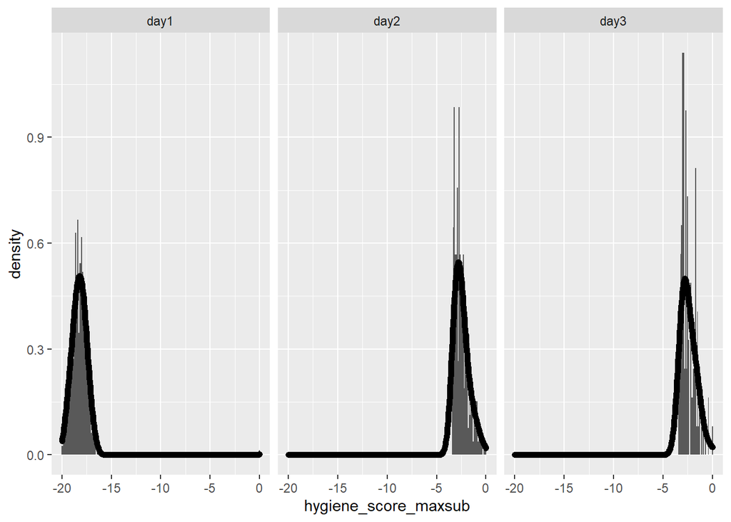

```r
# 변형 후 분포 확인.
festival.2 %>%
  ggplot(aes(x = hygiene_score_maxsub)) +
  geom_histogram(aes(y = ..density..), binwidth = 0.1) +
  geom_density(adjust = 2, lwd = 2) +
  facet_wrap(~ day)
```

# 4.비모수 통계분석

## (1) 범주변수 분석

- 카이제곱검정(chi-square test)
  - 정의: 두 개의 범주변수 간에 유의미한 연관성이 있는지 여부를 판단하는 데 사용되는 비모수 통계분석 방법.
  - 함수: `chisq.test()`를 사용.

> chisq.test(contingency table) **OR** chisq.test(범주변수 1, 범주변수 2)

```r
# contingency table 만들기.
mpg.table <- table(mpg$class, mpg$cyl)

# 카이제곱검정 시행하기.
chisq.test(mpg.table) # contingency table로 검정하기.
```

```
##
##  Pearson's Chi-squared test
##
## data:  mpg.table
## X-squared = 138.03, df = 18, p-value < 0.00000000000000022
```

```r
chisq.test(mpg$class, mpg$cyl) # 범주변수로 검정하기.
```

```
##
##  Pearson's Chi-squared test
##
## data:  mpg$class and mpg$cyl
## X-squared = 138.03, df = 18, p-value < 0.00000000000000022
```

```r
format(2.2e-16, scientific = F) # 지수를 실수로 바꾸기.
```

```
## [1] "0.00000000000000022"
```

## (2) 상관분석(correlation)

### A. 상관분석 시행 순서

- 통계적 가정 점검하기
  - 가정: 선형성(linearity) 및 정규성(normality) 검증하기.
  - 그래프: QQ-플롯, 히스토그램, 산점도 그려보기.
- 모형 적합도 확인하기(fitting model)
  - 통계적 가정 충족 시: 극단값이 없고 데이터가 등간/비율 척도일 경우, Pearson *r* 사용.
  - 통계적 가정 미충족 시: 극단값이 있고/있거나 데이터가 서열척도일 경우, Spearman *r*, Kendall의 τ(tau) 등을 사용.

### B. 데이터 시각화를 통해 통계적 가정 점검하기

- **GGally** 패키지의 `ggpairs` 함수: 산점도, 분포도, 상관계수를 동시에 나타내줌.

> ggpairs(데이터프레임, columns = c(“변수 1”, “변수 2”, “변수 3”…))

```r
# iris 데이터셋의 4개 등간척도 변수에 대한 산점도, 분포도, 상관계수 시각화하기.
library(GGally)
```

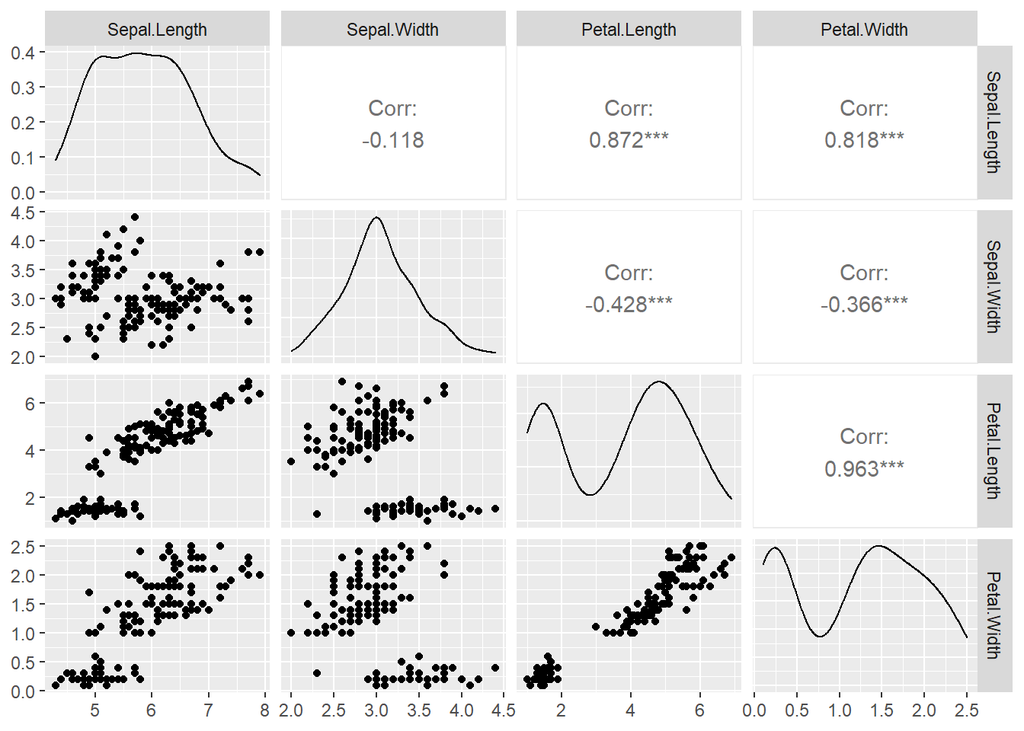

```r
iris <- as_tibble(iris)
ggpairs(iris, columns = c("Sepal.Length", "Sepal.Width", "Petal.Length", "Petal.Width"))
```

### C. 상관계수 산출하기

- 상관계수 산출 함수
  - **psych**의 `corr.test`
  - **correlation**의 `correlation`

> corr.test(등간/비율 척도 데이터, method = c(“pearson”, “spearman”, “kendall”), adjust = c(“holm”, “hochberg”, “hommel”, “bonferroni”, “BH”, “BY”, “fdr”, “none”), alpha = .05, ci = T)

> correlation(tibble, method = c(“pearson”, “spearman”, “kendall”, “biserial”), p_adjust = c(“holm”, “hochberg”, “hommel”, “bonferroni”, “BH”, “BY”, “fdr”, “somers”, “none”), ci = 0.95, digits = 소수점 이하 표기 숫자, ci_digits = 소수점 이하 표기 숫자)
- Pearson *r* 산출하기

```r
# iris 데이터셋의 4개 등간척도 변수에 대한 Pearson r 상관계수 구하기: corr.test 함수 사용.
library(psych)
iris %>%
  dplyr::select(1:4) %>%
  corr.test() # Pearson r이 디폴트이므로 method 논항을 정의할 필요 없음.
```

```
## Call:corr.test(x = .)
## Correlation matrix
##              Sepal.Length Sepal.Width Petal.Length Petal.Width
## Sepal.Length         1.00       -0.12         0.87        0.82
## Sepal.Width         -0.12        1.00        -0.43       -0.37
## Petal.Length         0.87       -0.43         1.00        0.96
## Petal.Width          0.82       -0.37         0.96        1.00
## Sample Size
## [1] 150
## Probability values (Entries above the diagonal are adjusted for multiple tests.)
##              Sepal.Length Sepal.Width Petal.Length Petal.Width
## Sepal.Length         0.00        0.15            0           0
## Sepal.Width          0.15        0.00            0           0
## Petal.Length         0.00        0.00            0           0
## Petal.Width          0.00        0.00            0           0
##
##  To see confidence intervals of the correlations, print with the short=FALSE option
```

```r
# iris 데이터셋의 4개 등간척도 변수에 대한 Pearson r 상관계수 구하기: correlation 함수 사용.
library(correlation)
iris %>%
  correlation(digits = 3) # Pearson r이 디폴트이므로 method 논항을 정의할 필요 없음.
```

```
## # Correlation Matrix (pearson-method)
##
## Parameter1   |   Parameter2 |      r |         95% CI | t(148) |         p
## --------------------------------------------------------------------------
## Sepal.Length |  Sepal.Width | -0.118 | [-0.27,  0.04] | -1.440 | 0.152
## Sepal.Length | Petal.Length |  0.872 | [ 0.83,  0.91] | 21.646 | < .001***
## Sepal.Length |  Petal.Width |  0.818 | [ 0.76,  0.86] | 17.296 | < .001***
## Sepal.Width  | Petal.Length | -0.428 | [-0.55, -0.29] | -5.768 | < .001***
## Sepal.Width  |  Petal.Width | -0.366 | [-0.50, -0.22] | -4.786 | < .001***
## Petal.Length |  Petal.Width |  0.963 | [ 0.95,  0.97] | 43.387 | < .001***
##
## p-value adjustment method: Holm (1979)
## Observations: 150
```

- Spearman *r* 산출하기
  - biggest_liar 데이터셋: 영국의 Wasdale에서 열리는 World’s Biggest Liar competition 참여자 68명의 창의성 설문결과와 대회순위 그리고 이전 대회 참여 여부를 기록한 데이터셋.
  - 가설: 창의성과 대회순위 간에 상관이 있는가?
  - Spearman *r* 사용 이유: 대회순위는 서열척도이므로, 서열척도 변수와 등간척도 변수 간 상관계수는 Pearson *r* 이외의 비모수 상관분석 방법을 사용해야 함.

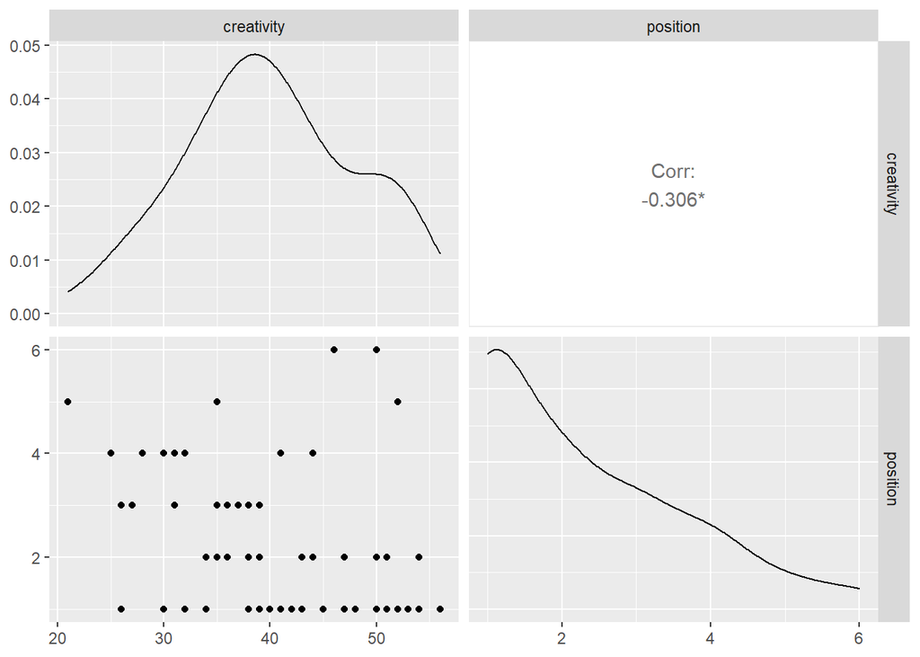

```r
# biggest_liar 데이터셋 불러오기.
load("biggest_liar.rda")

# biggest_liar 참여자들의 창의성과 대회순위 간 연관성 시각화하기.
ggpairs(biggest_liar, columns = c("creativity", "position"))
```

```r
# corr.test 함수 사용.
biggest_liar %>%
  dplyr::select(2, 3) %>%
  corr.test(method = "spearman")
```

```
## Call:corr.test(x = ., method = "spearman")
## Correlation matrix
##            creativity position
## creativity       1.00    -0.37
## position        -0.37     1.00
## Sample Size
## [1] 68
## Probability values (Entries above the diagonal are adjusted for multiple tests.)
##            creativity position
## creativity          0        0
## position            0        0
##
##  To see confidence intervals of the correlations, print with the short=FALSE option
```

```r
# correlation 함수 사용.
biggest_liar %>%
  dplyr::select(2, 3) %>%
  correlation(method = "spearman")
```

```
## # Correlation Matrix (spearman-method)
##
## Parameter1 | Parameter2 |   rho |         95% CI |        S |       p
## ---------------------------------------------------------------------
## creativity |   position | -0.37 | [-0.57, -0.14] | 71948.40 | 0.002**
##
## p-value adjustment method: Holm (1979)
## Observations: 68
```

- Kentall의 tau 산출하기
  - 가설: 창의성과 대회순위 간에 상관이 있는가?
  - Kentall의 tau 사용 이유
    - 서열척도 변수가 포함되어 있을 경우.
    - 데이터셋의 규모가 작을 경우.
    - 동일한 순위(rank)가 다수 중복될 경우.

```r
# corr.test 함수 사용.
biggest_liar %>%
  dplyr::select(2, 3) %>%
  corr.test(method = "kendall")
```

```
## Call:corr.test(x = ., method = "kendall")
## Correlation matrix
##            creativity position
## creativity        1.0     -0.3
## position         -0.3      1.0
## Sample Size
## [1] 68
## Probability values (Entries above the diagonal are adjusted for multiple tests.)
##            creativity position
## creativity       0.00     0.01
## position         0.01     0.00
##
##  To see confidence intervals of the correlations, print with the short=FALSE option
```

```r
# correlation 함수 사용.
biggest_liar %>%
  dplyr::select(2, 3) %>%
  correlation(method = "kendall")
```

```
## # Correlation Matrix (kendall-method)
##
## Parameter1 | Parameter2 |   tau |         95% CI |     z |       p
## ------------------------------------------------------------------
## creativity |   position | -0.30 | [-0.44, -0.15] | -3.23 | 0.001**
##
## p-value adjustment method: Holm (1979)
## Observations: 68
```

# 5. 모수 통계분석

## (1) 일반선형모형(general linear model, GLM)

### A. 일반선형모형이란?

- 일반선형모형의 정의
  - 우리는 데이터셋을 가장 잘 설명할 수 있는 모형을 찾고자 함.
  - 이를 위해서 한 개 이상의 예측변수를 통해 결과변수를 예측하는 모형을 수립할 수 있음.
  - 해당 모형이 데이터셋의 트렌드를 잘 반영하고 있다면, 데이터셋을 일직선으로 요약할 수 있음.
  - 선형회귀분석(linear regression analysis)와 같은 개념.

**[그림 1] 일반선형모형 분석 과정**

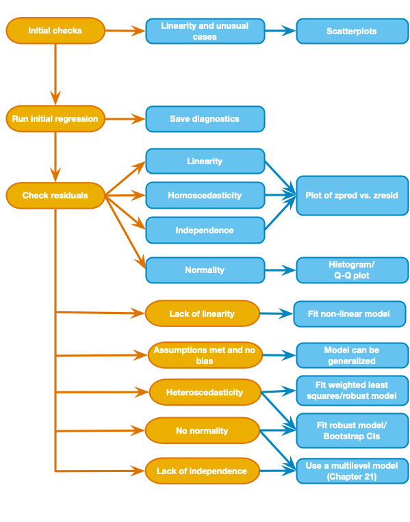

- 통계적 가정 점검하기
  - 선형성(linearity).
  - 등분산성(homoscedasticity): 잔차(오차)의 분산이 예측변수의 각 관찰값마다 동일한 값을 나타내야 함.
  - 독립성(independence): 관찰값은 모두 독립적이어야 함. 특정 관찰값이 다른 관찰값에 의존하지 않아야 함.
  - 정규성(nomarlity).

**[그림 2] 등분산성의 개념**

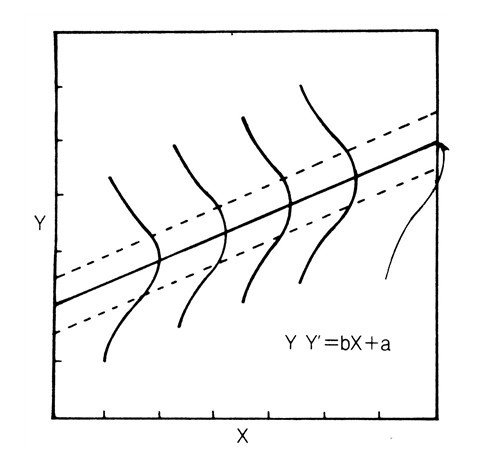

- 데이터 시각화를 통해 통계적 가정 점검하기.
  - 데이터셋(`album_sales`) 개관
    - `sales`: 공개 1주일 간 앨범의 판매량.
    - `adverts`: 공개 후 앨범 홍보에 사용된 광고 지출액.
    - `airplay`: 공개 후 1주일 간 라디오 방송 횟수.
    - `image`: 해당 가수의 외모(10점 만점).

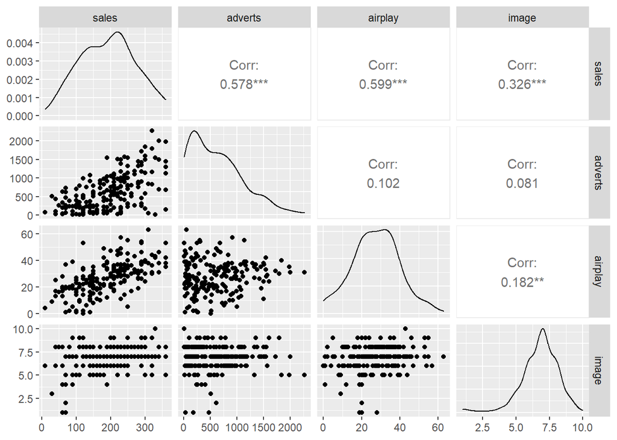

```r
# album_sales 데이터셋의 세 가지 예측변수와 한 가지 결과변수(sales) 간의 관계 살펴보기.
load("album_sales.rda")
library(GGally)
ggpairs(album_sales, columns = c("sales", "adverts", "airplay", "image"))
```

#### 1) 예측변수가 한 개일 경우

- 한 개의 예측변수로 일반선형모형 적합도 측정하기
  - 개념적 공식:

$$Y_{i}=b_{0}+b_{1}X_{i}+ϵ_{i}$$

$$Sales_{i}=b_{0}+b_{1}Advertising_{i}+ϵ_{i}$$

- R 코드: `~`는 “~라는 예측변수**를 통해** 결과변수를 **예측한다**”라는 의미를 지님.
- **broom** 패키지: 모형의 핵심정보 추출해줌.
  - `glance` 함수: 전반적인 모형 적합도 통계값 추출
    - `r.squared`: *R* 제곱 값.
    - `adj.r.squared`: 조정된 *R* 제곱 값.
    - `statistic`: 영가설 검증에 대한 *F*-통계량.
    - `p.value`: 유의확률. 영가설이 참일 경우 해당 *F*-통계량이 산출될 확률.
    - `sigma`: 잔차 분산의 제곱근.
  - `tidy` 함수: 모형의 모수(model parameters) 추출
    - `estimate`: *b* 값.
    - `std.error`: 표준오차.
    - `statistic`: *b* 값이 0보다 유의미하게 큰지 여부에 대한 *t*-검정 값.
    - `p.value`: 유의확률. *p* $<$ .05일 경우, *b* 값이 0보다 유의미하게 큰 것으로 간주.
- `na.action`: 결측값을 어떻게 처리할 것인지에 대한 논항
  - `na.fail`: 결측값 있을 경우 모형 적합도 측정 불가.
  - `na.omit`: 결측값을 물리적으로 제거. 100개의 관찰값 중 10개가 결측값이면 원래 데이터셋에서 90개의 관찰값만 남겨둠.
  - `na.exclude`: 모델로부터 결측값을 배제함. 100개의 관찰값 중 10개가 결측값이면 90개의 관찰값만 가지고 모형 적합도를 구함. 그러나 결측값을 지닌 관찰값에 대해서는 원래 데이터셋에 `NA`를 넣어두어 100개의 관찰값을 유지함.

> my_model <- lm(결과변수 ~ 예측변수(들), data = 데이터프레임, na.action = c(na.fail, na.omit, na.exclude))

```r
# 광고 지출액(adverts)를 통해 앨범 판매량 예측하기.
album_lm <- lm(sales ~ adverts, data = album_sales, na.action = na.exclude)

# 모형에 관한 정보 추출하기: R의 기본함수를 이용하는 경우.
summary(album_lm)
```

```
##
## Call:
## lm(formula = sales ~ adverts, data = album_sales, na.action = na.exclude)
##
## Residuals:
##      Min       1Q   Median       3Q      Max
## -152.949  -43.796   -0.393   37.040  211.866
##
## Coefficients:
##               Estimate Std. Error t value            Pr(>|t|)
## (Intercept) 134.139938   7.536575  17.799 <0.0000000000000002 ***
## adverts       0.096124   0.009632   9.979 <0.0000000000000002 ***
## ---
## Signif. codes:  0 '***' 0.001 '**' 0.01 '*' 0.05 '.' 0.1 ' ' 1
##
## Residual standard error: 65.99 on 198 degrees of freedom
## Multiple R-squared:  0.3346, Adjusted R-squared:  0.3313
## F-statistic: 99.59 on 1 and 198 DF,  p-value: < 0.00000000000000022
```

```r
# 모형에 관한 정보 추출하기: broom 패키지의 함수를 이용하는 경우.
library(broom)
glance(album_lm) # 모형 적합도 정보.
```

```
## # A tibble: 1 x 12
##   r.squared adj.r.squared sigma statistic  p.value    df logLik   AIC   BIC
##       <dbl>         <dbl> <dbl>     <dbl>    <dbl> <dbl>  <dbl> <dbl> <dbl>
## 1     0.335         0.331  66.0      99.6 2.94e-19     1 -1121. 2247. 2257.
## # ... with 3 more variables: deviance <dbl>, df.residual <int>, nobs <int>
```

```r
tidy(album_lm) # 모형의 모수 정보.
```

```
## # A tibble: 2 x 5
##   term        estimate std.error statistic  p.value
##   <chr>          <dbl>     <dbl>     <dbl>    <dbl>
## 1 (Intercept) 134.       7.54        17.8  5.97e-43
## 2 adverts       0.0961   0.00963      9.98 2.94e-19
```

- 일반선형모형의 해석: 100,000파운드를 신규 앨범 광고에 지출할 경우, 앨범 판매량은 약 144,000장 정도가 될 것.

$$Sales_{i}=b_{0}+b_{1}Advertising_{i}+ϵ_{i}$$
$$Sales_{i}=134.14+(0.096×Advertising_{i})+ϵ_{i}$$
$$Sales_{i}=134.14+(0.096×100)+ϵ_{i} =
143.74$$

#### 2) 예측변수가 여러 개일 경우

- 여러 개의 예측변수로 일반선형모형 적합도 측정하기.
  - 개념적 공식:

$$Y_{i}=b_{0}+b_{1}X_{1i}+b_{2}X_{2i}+...++b_{n}X_{ni}+ϵ_{i}$$
$$Sales_{i}=b_{0}+b_{1}Advertising_{i}+b_{2}Airplay_{i}+b_{3}Image_{i}+ϵ_{i}$$

```r
# 광고 지출액(adverts), 라디오 방송 횟수(airplay), 가수의 외모(image)를 통해 앨범 판매량 예측하기.
album_full_lm <- lm(sales ~ adverts + airplay + image, data = album_sales, na.action = na.exclude)

# 모형에 관한 정보 추출하기: R의 기본함수를 이용하는 경우.
summary(album_full_lm)
```

```
##
## Call:
## lm(formula = sales ~ adverts + airplay + image, data = album_sales,
##     na.action = na.exclude)
##
## Residuals:
##      Min       1Q   Median       3Q      Max
## -121.324  -28.336   -0.451   28.967  144.132
##
## Coefficients:
##               Estimate Std. Error t value             Pr(>|t|)
## (Intercept) -26.612958  17.350001  -1.534                0.127
## adverts       0.084885   0.006923  12.261 < 0.0000000000000002 ***
## airplay       3.367425   0.277771  12.123 < 0.0000000000000002 ***
## image        11.086335   2.437849   4.548           0.00000949 ***
## ---
## Signif. codes:  0 '***' 0.001 '**' 0.01 '*' 0.05 '.' 0.1 ' ' 1
##
## Residual standard error: 47.09 on 196 degrees of freedom
## Multiple R-squared:  0.6647, Adjusted R-squared:  0.6595
## F-statistic: 129.5 on 3 and 196 DF,  p-value: < 0.00000000000000022
```

```r
# 모형에 관한 정보 추출하기: broom 패키지의 함수를 이용하는 경우.
library(broom)
glance(album_full_lm) # 모형 적합도 정보.
```

```
## # A tibble: 1 x 12
##   r.squared adj.r.squared sigma statistic  p.value    df logLik   AIC   BIC
##       <dbl>         <dbl> <dbl>     <dbl>    <dbl> <dbl>  <dbl> <dbl> <dbl>
## 1     0.665         0.660  47.1      129. 2.88e-46     3 -1052. 2114. 2131.
## # ... with 3 more variables: deviance <dbl>, df.residual <int>, nobs <int>
```

```r
tidy(album_full_lm) # 모형의 모수 정보.
```

```
## # A tibble: 4 x 5
##   term        estimate std.error statistic  p.value
##   <chr>          <dbl>     <dbl>     <dbl>    <dbl>
## 1 (Intercept) -26.6     17.4         -1.53 1.27e- 1
## 2 adverts       0.0849   0.00692     12.3  5.05e-26
## 3 airplay       3.37     0.278       12.1  1.33e-25
## 4 image        11.1      2.44         4.55 9.49e- 6
```

- 여러 개의 모형의 적합도 비교하기
  - `Res.Df`: 두 모형 간 자유도의 차이([EX] 여기서는 변수 두 개의 차이).
  - `RSS`: Residual Sum of Squares. Sum of Squared Errors(SSE)로도 알려짐. 두 모형의 error sum of squares에 해당. `RSS`가 작을수록 모형 적합도가 높음을 의미.
  - `Sum of sq`: Sum of squares. model 1의 RSS - model 2의 RSS.
  - `F`: 두 모형의 *R*<sup>2</sup> 간 차이에 대한 *F*-검정 통계값.
  - 결론: *F*(2, 196) = 96.45, *p* $<$ .001.

> anova(모형 1, 모형 2, …, 모형 *n*)

```r
# album_lm과 album_full_lm의 모형 적합도 비교하기.
anova(album_lm, album_full_lm)
```

```
## Analysis of Variance Table
##
## Model 1: sales ~ adverts
## Model 2: sales ~ adverts + airplay + image
##   Res.Df    RSS Df Sum of Sq      F                Pr(>F)
## 1    198 862264
## 2    196 434575  2    427690 96.447 < 0.00000000000000022 ***
## ---
## Signif. codes:  0 '***' 0.001 '**' 0.01 '*' 0.05 '.' 0.1 ' ' 1
```

```r
anova(album_lm, album_full_lm) %>%
  tidy()
```

```
## # A tibble: 2 x 6
##   res.df     rss    df   sumsq statistic   p.value
##    <dbl>   <dbl> <dbl>   <dbl>     <dbl>     <dbl>
## 1    198 862264.    NA     NA       NA   NA
## 2    196 434575.     2 427690.      96.4  6.88e-30
```

#### 3) 플롯을 통해 모형 진단하기

- 모형의 선형성, 잔차/오차의 정규성, 등분산성 진단
  - R의 내장함수 `plot` 사용.
  - **ggfortify**의 함수 `autoplot` 사용.
- `which` 논항의 선택지 설명명
  1. 모형을 통해 예측된 값(*x*축)과 잔차(*y*축) 플롯. 선형성과 등분산성 점검에 사용.
  2. 표준화된 잔차의 QQ-플롯. 잔차의 정규성 점검에 사용.
  3. 모형을 통해 예측된 값(*x*축)과 표준화된 잔차의 제곱근(*y*축) 플롯. 1번 플롯의 변종으로, 선형성과 등분산성 점검에 사용.
  4. 관찰값 번호(*x*축)와 Cook의 거리(*y*축) 플롯. 모형에 영향을 미치는 관찰값(Cook의 거리가 큰 관찰값) 파악에 도움을 줌.
  5. 개별 관찰값의 leverage 값(*x*축)과 표준화된 잔차(*y*축) 플롯. 모형에 영향을 미치는 관찰값과 극단값 파악에 도움을 줌. leverage 값은 개별 관찰값이 모형에 미치는 영향력을 가리키며, Cook의 거리와도 관련이 있음.
  6. 개별 관찰값의 leverage 값(*x*축)과 그에 대응하는 Cook의 거리(*y*축) 플롯.모형에 영향을 미치는 관찰값과 극단값 파악에 도움을 줌.

> autoplot(모형 이름, which = 원하는 플롯의 수/번호) *OR* plot(모형 이름, which = 원하는 플롯의 수/번호)

**[그림 3] 잔차 플롯(1번 플롯)의 사례**

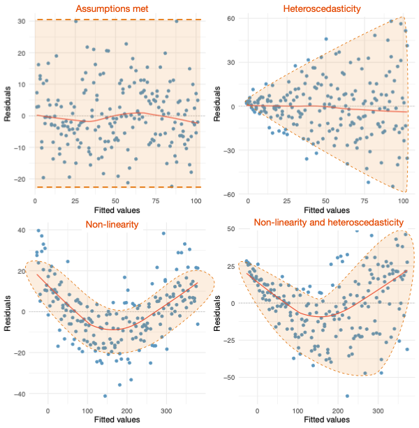

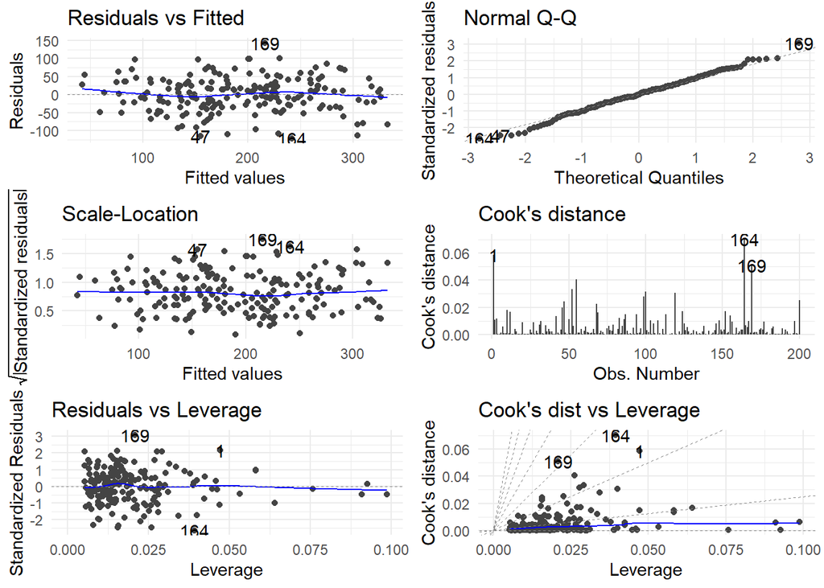

```r
# album_full_lm 진단하기(1-6번 플롯 모두 그려보기).
library(ggfortify)
autoplot(album_full_lm, which = 1:6) +
  theme_minimal() # 플롯 배경 간소화하기.
```

- 모형에 영향을 미치는 관찰값과 극단값 파악하기
  - **broom** 패키지의 `augment` 함수를 통해 Cook의 거리와 표준화된 잔차를 구할 수 있음.
  - 표준화된 잔차: 95%는 절대값 1.96 내에, 99%는 2.5 내에 있어야 함. 3 이상은 극단값으로 간주.
  - Cook의 거리: 평균의 3배 이상, 1 이상이면 극단값으로 간주.
  - 극단값들을 제거한 뒤 모형 내 값들이 어떻게 그리고 얼마나 변화하는지 살펴볼 것.

```r
# augment 함수를 통해 관찰값마다 Cook의 거리와 표준화된 잔차를 구함.
album_full_rsd <- album_full_lm %>%
  augment(., data = album_sales) %>%
  tibble::rowid_to_column(var = "case_no") # case_no라는 칼럼을 만들어 행 번호 값을 거기에 넣겠다는 뜻.

# 표준화된 잔차를 바탕으로 극단값 파악하기.
album_full_rsd %>%
  filter(abs(.std.resid) >= 1.96) %>%
  dplyr::select(case_no, .std.resid, .resid) %>%
  arrange(.std.resid)
```

```
## # A tibble: 13 x 3
##    case_no .std.resid .resid
##      <int>      <dbl>  <dbl>
##  1     164      -2.63 -121.
##  2      47      -2.46 -115.
##  3      55      -2.46 -114.
##  4      68      -2.36 -110.
##  5       2      -2.32 -109.
##  6     200      -2.09  -97.2
##  7     167      -2.00  -93.6
##  8     100       2.10   97.3
##  9      52       2.10   97.4
## 10      61       2.10   98.8
## 11      10       2.13   99.5
## 12       1       2.18  100.
## 13     169       3.09  144.
```

```r
# Cook의 거리를 바탕으로 극단값 파악하기(1 이상인 값 찾기).
album_full_rsd %>%
  arrange(desc(.cooksd)) %>%
  dplyr::select(case_no, .cooksd)
```

```
## # A tibble: 200 x 2
##    case_no .cooksd
##      <int>   <dbl>
##  1     164  0.0708
##  2       1  0.0587
##  3     169  0.0509
##  4      55  0.0404
##  5      52  0.0332
##  6     100  0.0314
##  7     119  0.0308
##  8      99  0.0281
##  9     200  0.0251
## 10      47  0.0241
## # ... with 190 more rows
```

#### 4) robust 선형모형

```r
# robust 패키지 불러오기.
library(robust)
```

```r
# robust의 lmRob 함수 통해 모형 적합도 측정하기.
album_full_rob <- lmRob(sales ~ adverts + airplay + image, data = album_sales, na.action = na.exclude)
summary(album_full_rob)
```

```
##
## Call:
## lmRob(formula = sales ~ adverts + airplay + image, data = album_sales,
##     na.action = na.exclude)
##
## Residuals:
##     Min      1Q  Median      3Q     Max
## -124.62  -30.47   -1.76   28.89  141.35
##
## Coefficients:
##               Estimate Std. Error t value             Pr(>|t|)
## (Intercept) -31.523201  21.098348  -1.494             0.136756
## adverts       0.085295   0.008501  10.033 < 0.0000000000000002 ***
## airplay       3.418749   0.339017  10.084 < 0.0000000000000002 ***
## image        11.771441   2.973559   3.959             0.000105 ***
## ---
## Signif. codes:  0 '***' 0.001 '**' 0.01 '*' 0.05 '.' 0.1 ' ' 1
##
## Residual standard error: 44.61 on 196 degrees of freedom
## Multiple R-Squared: 0.5785
##
## Test for Bias:
##             statistic p-value
## M-estimate      2.299  0.6809
## LS-estimate     7.659  0.1049
```

```r
# 원래 일반선형모형 적합도와 비교하기.
summary(album_full_lm)
```

```
##
## Call:
## lm(formula = sales ~ adverts + airplay + image, data = album_sales,
##     na.action = na.exclude)
##
## Residuals:
##      Min       1Q   Median       3Q      Max
## -121.324  -28.336   -0.451   28.967  144.132
##
## Coefficients:
##               Estimate Std. Error t value             Pr(>|t|)
## (Intercept) -26.612958  17.350001  -1.534                0.127
## adverts       0.084885   0.006923  12.261 < 0.0000000000000002 ***
## airplay       3.367425   0.277771  12.123 < 0.0000000000000002 ***
## image        11.086335   2.437849   4.548           0.00000949 ***
## ---
## Signif. codes:  0 '***' 0.001 '**' 0.01 '*' 0.05 '.' 0.1 ' ' 1
##
## Residual standard error: 47.09 on 196 degrees of freedom
## Multiple R-squared:  0.6647, Adjusted R-squared:  0.6595
## F-statistic: 129.5 on 3 and 196 DF,  p-value: < 0.00000000000000022
```

### B. 두 개의 평균 비교하기

**[그림 4] 두 개의 평균 비교(*t*-검정) 분석 과정**

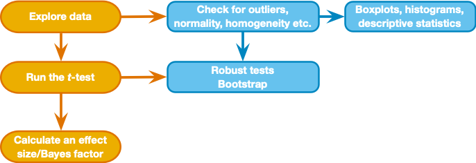

#### 1) 기술통계량 분석 및 데이터 시각화를 통해 통계적 가정 점검하기

- 데이터셋 개관(`cloak_tib`)
  - `id`: 참여자 이름. 총 24명.
  - `cloak`: 투명 망토를 입었는지 여부.
  - `mischief`: 장난끼 척도.
- 기술통계량 구하기.

```r
# cloak_tib 데이터셋 불러오기.
load("cloak_tib.rda")

# 숫자로 되어 있는 변수를 범주변수(요인[factor])로 바꾸기.
cloak_tib <- cloak_tib %>%
  mutate(cloak = as_factor(cloak),
         id = as_factor(id))

# 기술통계량 구하기: tidyverse를 이용하는 경우.
cloak_tib %>%
  group_by(cloak) %>%
  summarise(
    n = n(),
    mean = mean(mischief),
    ci_lower = ggplot2::mean_cl_normal(mischief)$xmax,
    ci_upper = ggplot2::mean_cl_normal(mischief)$ymax)
```

```
## # A tibble: 2 x 4
##   cloak        n  mean ci_upper
##   <fct>    <int> <dbl>    <dbl>
## 1 No cloak    12  3.75     4.97
## 2 Cloak       12  5        6.05
```

```r
# 기술통계량 구하기: psych를 이용하는 경우.
describeBy(cloak_tib, cloak_tib$cloak)
```

```
##
##  Descriptive statistics by group
## group: No cloak
##          vars  n mean   sd median trimmed  mad min max range skew kurtosis   se
## id*         1 12 6.50 3.61    6.5     6.5 4.45   1  12    11  0.0    -1.50 1.04
## cloak*      2 12 1.00 0.00    1.0     1.0 0.00   1   1     0  NaN      NaN 0.00
## mischief    3 12 3.75 1.91    4.0     3.9 1.48   0   6     6 -0.6    -0.99 0.55
## ------------------------------------------------------------
## group: Cloak
##          vars  n mean   sd median trimmed  mad min max range skew kurtosis   se
## id*         1 12 18.5 3.61   18.5    18.5 4.45  13  24    11    0    -1.50 1.04
## cloak*      2 12  2.0 0.00    2.0     2.0 0.00   2   2     0  NaN      NaN 0.00
## mischief    3 12  5.0 1.65    5.0     5.0 1.48   2   8     6    0    -0.78 0.48
```

- 데이터 시각화하기.

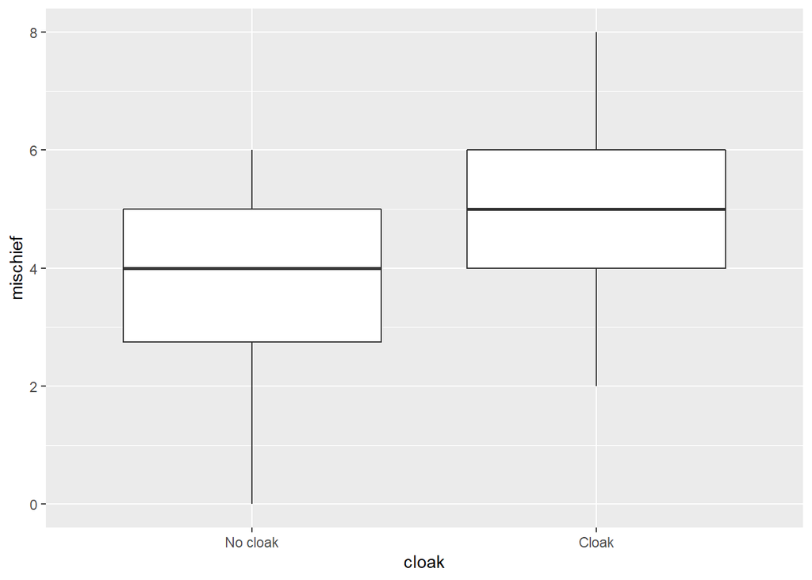

```r
# 상자 그래프 그리기.
cloak_tib %>%
  ggplot(aes(x = cloak, y = mischief)) + # 범주변수는 망토 착용 여부, 관찰값은 장난끼 척도.
  geom_boxplot()
```

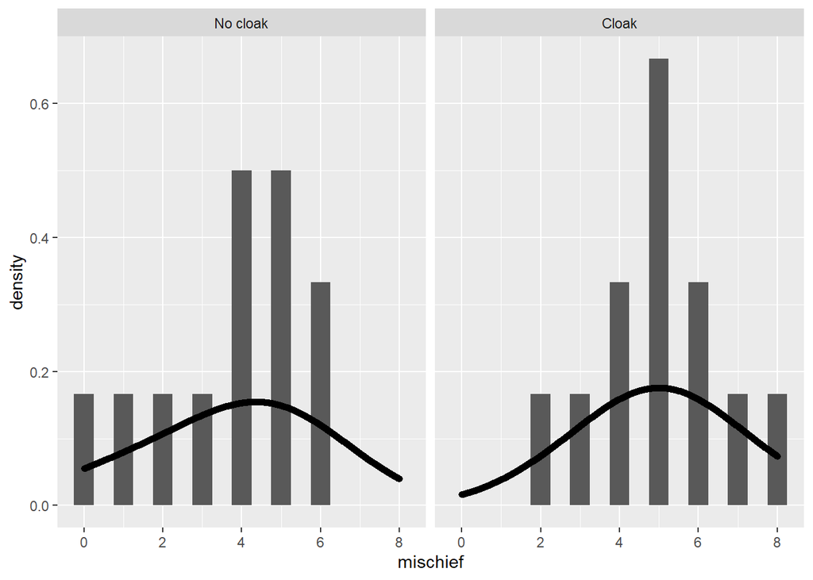

```r
# 히스토그램 그리기.
cloak_tib %>%
  ggplot(aes(mischief)) +
  geom_histogram(aes(y = ..density..), binwidth = 0.5) +
  geom_density(adjust = 2, lwd = 2) +
  facet_wrap(~ cloak)
```

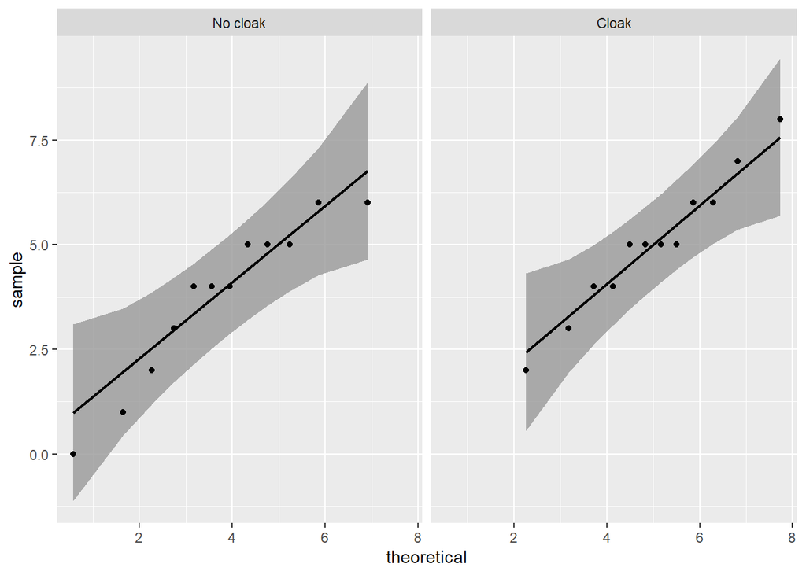

```r
# QQ-플롯 그리기.
library(qqplotr)
cloak_tib %>%
  ggplot(aes(sample = mischief)) +
  stat_qq_band() +
  stat_qq_line() +
  stat_qq_point() +
  facet_wrap(~ cloak)
```

#### 2) 독립표본 *t*-검정

- `t.test` 함수 논항 설명
  - `paired`: `F`면 독립표본 *t*-검정, `T`면 종속표본 *t*-검정.
  - `var.equal`: 두 집단 간 분산 동일성. `F`(디폴트)면 분산이 동일하지 않음, `T`면 분산이 동일함. 분산이 동일하지 않을 경우 Welch의 교정(Welch’s correction)를 적용.
  - `conf.level`: *p* 값과 신뢰구간에 대한 유의수준 결정. 디폴트는 0.95(95% 신뢰구간).
  - `na.action`: 결측값 처리 방법. `na.action = na.exclude`로 설정하는 것이 유용.

> *t*-검정 모형 <- t.test(종속변수 ~ 독립변수, data = 데이터프레임, paired = FALSE, var.equal = FALSE, conf.level = 0.95, na.action = na.exclude)

```r
# 독립표본 t-검정 실시.
cloak_tib_mod <- t.test(mischief ~ cloak, data = cloak_tib, na.action = na.exclude)
cloak_tib_mod
```

```
##
##  Welch Two Sample t-test
##
## data:  mischief by cloak
## t = -1.7135, df = 21.541, p-value = 0.101
## alternative hypothesis: true difference in means between group No cloak and group Cloak is not equal to 0
## 95 percent confidence interval:
##  -2.764798  0.264798
## sample estimates:
## mean in group No cloak    mean in group Cloak
##                   3.75                   5.00
```

```r
tidy(cloak_tib_mod)
```

```
## # A tibble: 1 x 10
##   estimate estimate1 estimate2 statistic p.value parameter conf.low conf.high
##      <dbl>     <dbl>     <dbl>     <dbl>   <dbl>     <dbl>    <dbl>     <dbl>
## 1    -1.25      3.75         5     -1.71   0.101      21.5    -2.76     0.265
## # ... with 2 more variables: method <chr>, alternative <chr>
```

> cohens_d(종속변수 ~ 독립변수, data = 데이터프레임, pooled_sd = TRUE, paired = FALSE)

```r
# 효과 크기 산출하기.
library(effectsize)
cohens_d(mischief ~ cloak, data = cloak_tib)
```

```
## Cohen's d |        95% CI
## -------------------------
## -0.70     | [-1.52, 0.13]
##
## - Estimated using pooled SD.
```

```r
hedges_g(mischief ~ cloak, data = cloak_tib)
```

```
## Hedges' g |        95% CI
## -------------------------
## -0.68     | [-1.47, 0.13]
##
## - Estimated using pooled SD.
```

```r
glass_delta(mischief ~ cloak, data = cloak_tib)
```

```
## Glass' delta |        95% CI
## ----------------------------
## -0.76        | [-1.66, 0.18]
```

#### 3) 종속표본 *t*-검정

- 데이터셋 개관(`cloak_rm_tib`): `cloak_tib`과 유사. 단, 같은 참여자가 투명 망토를 입었을 때와 입지 않았을 때를 비교함.

```r
# cloak_rm_tib 데이터셋 불러오기.
load("cloak_rm_tib.rda")

# 종속표본 t-검정 실시.
cloak_rm_tib_mod <- t.test(mischief ~ cloak, data = cloak_rm_tib, paired = T)
cloak_rm_tib_mod
```

```
##
##  Paired t-test
##
## data:  mischief by cloak
## t = 3.8044, df = 11, p-value = 0.002921
## alternative hypothesis: true difference in means is not equal to 0
## 95 percent confidence interval:
##  0.5268347 1.9731653
## sample estimates:
## mean of the differences
##                    1.25
```

```r
tidy(cloak_rm_tib_mod)
```

```
## # A tibble: 1 x 8
##   estimate statistic p.value parameter conf.low conf.high method     alternative
##      <dbl>     <dbl>   <dbl>     <dbl>    <dbl>     <dbl> <chr>      <chr>
## 1     1.25      3.80 0.00292        11    0.527      1.97 Paired t-~ two.sided
```

```r
# 효과 크기 산출하기.
cohens_d(mischief ~ cloak, data = cloak_rm_tib, paired = T)
```

```
## Cohen's d |       95% CI
## ------------------------
## 1.10      | [0.37, 1.89]
```

```r
hedges_g(mischief ~ cloak, data = cloak_rm_tib, paired = T)
```

```
## Hedges' g |       95% CI
## ------------------------
## 1.02      | [0.35, 1.76]
```

#### 4) robust 독립표본 *t*-검정

- **WRS2** 패키지의 `yuen` 또는 `yuenbt` 함수 논항
  - `tr`: 자료분포에서 양극단의 일정 퍼센트를 제외한 *trimmed mean*을 사용함. 20% 제외가 디폴트. 이는 낮은 쪽 극단의 20%와 높은 쪽 극단의 20%를 잘라낸 분포의 평균을 의미함.
  - `alpha`: 유의수준. 디폴트는 .05임.
  - `nboot`: 부트스래핑(bootstraping) 횟수. 599회가 디폴트. 2000 이하가 적절.
  - `side`: 신뢰구간을 대칭적으로 부트스트래핑하고자 할 경우 `side = T`로 설정. `side = T`로 해야 *p* 값을 구할 수 있음.

> yuen(종속변수 ~ 독립변수, data = 데이터프레임, tr = .2, alpha = .05, nboot = 1000, side = TRUE) yuenbt(종속변수 ~ 독립변수, data = 데이터프레임, tr = .2, alpha = .05, nboot = 1000, side = TRUE)

```r
# `yuen` 또는 `yuenbt` 함수로 robust 독립표본 t-검정 실시.
library(WRS2)
yuen(mischief ~ cloak, data = cloak_tib, nboot = 1000, side = T)
```

```
## Call:
## yuen(formula = mischief ~ cloak, data = cloak_tib, nboot = 1000,
##     side = T)
##
## Test statistic: 1.4771 (df = 12.26), p-value = 0.16487
##
## Trimmed mean difference:  -1
## 95 percent confidence interval:
## -2.4716     0.4716
##
## Explanatory measure of effect size: 0.4
```

```r
yuenbt(mischief ~ cloak, data = cloak_tib, nboot = 1000, side = T)
```

```
## Call:
## yuenbt(formula = mischief ~ cloak, data = cloak_tib, nboot = 1000,
##     side = T)
##
## Test statistic: -1.3607 (df = NA), p-value = 0.171
##
## Trimmed mean difference:  -1
## 95 percent confidence interval:
## -2.5732     0.5732
```

#### 5) robust 종속표본 *t*-검정

- **WRS2** 패키지의 `yuend` 함수 논항
  - `tr`: `yuen`과 동일.
  - 조건 1의 점수 변수, 조건 2의 점수 변수가 논항으로 투입됨.

> yuend(조건 1의 점수, 조건 2의 점수, tr = .2)

```r
# pivot_wider 함수를 통해 조건 1(no cloak)과 조건 2(cloak)으로 데이터셋 나누기.
cloak_messy_tib <- cloak_rm_tib %>%
  pivot_wider(id_cols = id,
              values_from = mischief,
              names_from = cloak)

# `yuend` 함수로 robust 종속표본 t-검정 실시.
yuend(cloak_messy_tib$Cloak, cloak_messy_tib$`No cloak`, tr = .2)
```

```
## Call:
## yuend(x = cloak_messy_tib$Cloak, y = cloak_messy_tib$`No cloak`,
##     tr = 0.2)
##
## Test statistic: 2.7027 (df = 7), p-value = 0.03052
##
## Trimmed mean difference:  1
## 95 percent confidence interval:
## 0.1251     1.8749
##
## Explanatory measure of effect size: 0.4
```